# Activity Recognition

Emel Aktas

26 July 2015

## Introduction

The aim of this project is to recognise activities of people using data recorded by wearable devices such as belts, gloves, arm bands as well as dumbbells equipped with a sensor. Participants are asked to perform Unilateral Dumbbell Biceps Curl in five different fashions; hence, there are five classes of activities to be recognised by the machine learning algorithm. The first activity is correct implementation of lifting whereas the remaining four represent common mistakes as follows:

- Class A: Exactly according to the specification
- Class B: Throwing the elbows to the front
- Class C: Lifting the dumbbell only halfway
- Class D: Lowering the dumbbell only halfway
- Class E: Throwing the hips to the front

To predict the activity class, a machine learning algorithm is built and then cross-validated. Subsequently, the out-of-sample error is estimated. This report primarily presents these three components of the project and also explains the rationale behind the choices made in this process. The report ends with brief conclusions.

## Model Building

The aim of the machine learning model is to predict the activity quality classes A-E as described above from sensor readings.

```r
# Read training data
training <- read.csv("pml-training.csv", na.strings=c("NA",""), header=T)

# Read problem sets
predictionset <- read.csv("pml-testing.csv", na.strings=c("NA",""), header=T)
# str(training) # check structure - commented out to save space
dim(training)
```

```
## [1] 19622   160
```

```r
# summary(training) # see the summary of variables - commented out to save space

# Load necessary packages
library(AppliedPredictiveModeling)
library(caret)
library(rattle)
```

```r
library(rpart.plot)
library(randomForest)
# Count how many NAs in each column to exclude those columns from the machine learning algorithm
NAs <- function(x) {
    as.vector(apply(x, 2, function(x) length(which(is.na(x)))))
}

# Count NAs in each column
columnNAcount <- NAs(training)
columnNAcount
```

```
##   [1]     0     0     0     0     0     0     0     0     0     0     0
##  [12] 19216 19216 19216 19216 19216 19216 19216 19216 19216 19216 19216
##  [23] 19216 19216 19216 19216 19216 19216 19216 19216 19216 19216 19216
##  [34] 19216 19216 19216     0     0     0     0     0     0     0     0
##  [45]     0     0     0     0     0 19216 19216 19216 19216 19216 19216
##  [56] 19216 19216 19216 19216     0     0     0     0     0     0     0
##  [67]     0     0 19216 19216 19216 19216 19216 19216 19216 19216 19216
##  [78] 19216 19216 19216 19216 19216 19216     0     0     0 19216 19216
##  [89] 19216 19216 19216 19216 19216 19216 19216 19216 19216 19216 19216
## [100] 19216 19216     0 19216 19216 19216 19216 19216 19216 19216 19216
## [111] 19216 19216     0     0     0     0     0     0     0     0     0
## [122]     0     0     0 19216 19216 19216 19216 19216 19216 19216 19216
## [133] 19216 19216 19216 19216 19216 19216 19216     0 19216 19216 19216
## [144] 19216 19216 19216 19216 19216 19216 19216     0     0     0     0
## [155]     0     0     0     0     0     0
```

```r
# Find the variables that do not have NAs
# Initialise variable to keep column names
newdatavars <- c()

# Develop the variable
for (i in 1:160){
  if(columnNAcount[i] == 0 ){
    newdatavars <- c(newdatavars, colnames(training)[i])
  }
}

newdatavars
```

```
##  [1] "X"                    "user_name"            "raw_timestamp_part_1"
##  [4] "raw_timestamp_part_2" "cvtd_timestamp"       "new_window"
##  [7] "num_window"           "roll_belt"            "pitch_belt"
## [10] "yaw_belt"             "total_accel_belt"     "gyros_belt_x"
## [13] "gyros_belt_y"         "gyros_belt_z"         "accel_belt_x"
## [16] "accel_belt_y"         "accel_belt_z"         "magnet_belt_x"
## [19] "magnet_belt_y"        "magnet_belt_z"        "roll_arm"
## [22] "pitch_arm"            "yaw_arm"              "total_accel_arm"
## [25] "gyros_arm_x"          "gyros_arm_y"          "gyros_arm_z"
## [28] "accel_arm_x"          "accel_arm_y"          "accel_arm_z"
## [31] "magnet_arm_x"         "magnet_arm_y"         "magnet_arm_z"
## [34] "roll_dumbbell"        "pitch_dumbbell"       "yaw_dumbbell"
## [37] "total_accel_dumbbell" "gyros_dumbbell_x"     "gyros_dumbbell_y"
## [40] "gyros_dumbbell_z"     "accel_dumbbell_x"     "accel_dumbbell_y"
## [43] "accel_dumbbell_z"     "magnet_dumbbell_x"    "magnet_dumbbell_y"
## [46] "magnet_dumbbell_z"    "roll_forearm"         "pitch_forearm"
## [49] "yaw_forearm"          "total_accel_forearm"  "gyros_forearm_x"
## [52] "gyros_forearm_y"      "gyros_forearm_z"      "accel_forearm_x"
## [55] "accel_forearm_y"      "accel_forearm_z"      "magnet_forearm_x"
## [58] "magnet_forearm_y"     "magnet_forearm_z"     "classe"
```

```r
# choose smaller data set
newtraining <- training[newdatavars]
dim(newtraining)
```

```
## [1] 19622    60
```

```r
# Covariates with no variability
nsv <- nearZeroVar(newtraining, saveMetrics=TRUE)
nsv
```

```
##                      freqRatio percentUnique zeroVar   nzv
## X                     1.000000  100.00000000   FALSE FALSE
## user_name             1.100679    0.03057792   FALSE FALSE
## raw_timestamp_part_1  1.000000    4.26562022   FALSE FALSE
## raw_timestamp_part_2  1.000000   85.53154622   FALSE FALSE
## cvtd_timestamp        1.000668    0.10192641   FALSE FALSE
## new_window           47.330049    0.01019264   FALSE  TRUE
## num_window            1.000000    4.37264295   FALSE FALSE
## roll_belt             1.101904    6.77810621   FALSE FALSE
## pitch_belt            1.036082    9.37722964   FALSE FALSE
## yaw_belt              1.058480    9.97349913   FALSE FALSE
## total_accel_belt      1.063160    0.14779329   FALSE FALSE
## gyros_belt_x          1.058651    0.71348486   FALSE FALSE
## gyros_belt_y          1.144000    0.35164611   FALSE FALSE
## gyros_belt_z          1.066214    0.86127816   FALSE FALSE
## accel_belt_x          1.055412    0.83579655   FALSE FALSE
## accel_belt_y          1.113725    0.72877383   FALSE FALSE
## accel_belt_z          1.078767    1.52379982   FALSE FALSE
## magnet_belt_x         1.090141    1.66649679   FALSE FALSE
## magnet_belt_y         1.099688    1.51870350   FALSE FALSE
## magnet_belt_z         1.006369    2.32901845   FALSE FALSE
## roll_arm             52.338462   13.52563449   FALSE FALSE
## pitch_arm            87.256410   15.73234125   FALSE FALSE
## yaw_arm              33.029126   14.65701763   FALSE FALSE
## total_accel_arm       1.024526    0.33635715   FALSE FALSE
## gyros_arm_x           1.015504    3.27693405   FALSE FALSE
## gyros_arm_y           1.454369    1.91621649   FALSE FALSE
## gyros_arm_z           1.110687    1.26388747   FALSE FALSE
## accel_arm_x           1.017341    3.95984099   FALSE FALSE
## accel_arm_y           1.140187    2.73672409   FALSE FALSE
## accel_arm_z           1.128000    4.03628580   FALSE FALSE
## magnet_arm_x          1.000000    6.82397309   FALSE FALSE
## magnet_arm_y          1.056818    4.44399144   FALSE FALSE
## magnet_arm_z          1.036364    6.44684538   FALSE FALSE
## roll_dumbbell         1.022388   84.20650290   FALSE FALSE
## pitch_dumbbell        2.277372   81.74498012   FALSE FALSE
## yaw_dumbbell          1.132231   83.48282540   FALSE FALSE
## total_accel_dumbbell  1.072634    0.21914178   FALSE FALSE
## gyros_dumbbell_x      1.003268    1.22821323   FALSE FALSE
## gyros_dumbbell_y      1.264957    1.41677709   FALSE FALSE
## gyros_dumbbell_z      1.060100    1.04984201   FALSE FALSE
## accel_dumbbell_x      1.018018    2.16593619   FALSE FALSE
## accel_dumbbell_y      1.053061    2.37488533   FALSE FALSE
## accel_dumbbell_z      1.133333    2.08949139   FALSE FALSE
## magnet_dumbbell_x     1.098266    5.74864948   FALSE FALSE
## magnet_dumbbell_y     1.197740    4.30129447   FALSE FALSE
## magnet_dumbbell_z     1.020833    3.44511263   FALSE FALSE
## roll_forearm         11.589286   11.08959331   FALSE FALSE
## pitch_forearm        65.983051   14.85577413   FALSE FALSE
## yaw_forearm          15.322835   10.14677403   FALSE FALSE
## total_accel_forearm   1.128928    0.35674243   FALSE FALSE
## gyros_forearm_x       1.059273    1.51870350   FALSE FALSE
## gyros_forearm_y       1.036554    3.77637346   FALSE FALSE
## gyros_forearm_z       1.122917    1.56457038   FALSE FALSE
## accel_forearm_x       1.126437    4.04647844   FALSE FALSE
## accel_forearm_y       1.059406    5.11160942   FALSE FALSE
## accel_forearm_z       1.006250    2.95586586   FALSE FALSE
## magnet_forearm_x      1.012346    7.76679238   FALSE FALSE
## magnet_forearm_y      1.246914    9.54031189   FALSE FALSE
## magnet_forearm_z      1.000000    8.57710733   FALSE FALSE
## classe                1.469581    0.02548160   FALSE FALSE
```

```r
# A quick look suggests new_window is an NZV. Delete new_window
newtraining <- newtraining[, -which(names(newtraining) %in% c("new_window"))]
str(newtraining)
```

```
## 'data.frame':    19622 obs. of  59 variables:
##  $ X                   : int  1 2 3 4 5 6 7 8 9 10 ...
##  $ user_name           : Factor w/ 6 levels "adelmo","carlitos",..: 2 2 2 2 2 2 2 2 2 2 ...
##  $ raw_timestamp_part_1: int  1323084231 1323084231 1323084231 1323084232 1323084232 1323084232 1323084232 1323084232 1323084232 1323084232 ...
##  $ raw_timestamp_part_2: int  788290 808298 820366 120339 196328 304277 368296 440390 484323 484434 ...
##  $ cvtd_timestamp      : Factor w/ 20 levels "02/12/2011 13:32",..: 9 9 9 9 9 9 9 9 9 9 ...
##  $ num_window          : int  11 11 11 12 12 12 12 12 12 12 ...
##  $ roll_belt           : num  1.41 1.41 1.42 1.48 1.48 1.45 1.42 1.42 1.43 1.45 ...
##  $ pitch_belt          : num  8.07 8.07 8.07 8.05 8.07 8.06 8.09 8.13 8.16 8.17 ...
##  $ yaw_belt            : num  -94.4 -94.4 -94.4 -94.4 -94.4 -94.4 -94.4 -94.4 -94.4 -94.4 ...
##  $ total_accel_belt    : int  3 3 3 3 3 3 3 3 3 3 ...
##  $ gyros_belt_x        : num  0 0.02 0 0.02 0.02 0.02 0.02 0.02 0.02 0.03 ...
##  $ gyros_belt_y        : num  0 0 0 0 0.02 0 0 0 0 0 ...
##  $ gyros_belt_z        : num  -0.02 -0.02 -0.02 -0.03 -0.02 -0.02 -0.02 -0.02 -0.02 0 ...
##  $ accel_belt_x        : int  -21 -22 -20 -22 -21 -21 -22 -22 -20 -21 ...
```

[output cut: 45 more lines]

```r
# Remove columns 1-6 which will not be needed for prediction
newtraining <- newtraining[-c(1:6)]

# Split data into training and testing data
inTrain <- createDataPartition(newtraining$classe, p = .75, list = F)
trainingdata <- newtraining[inTrain,]
testingdata <- newtraining[-inTrain,]
```

## Cross-validation

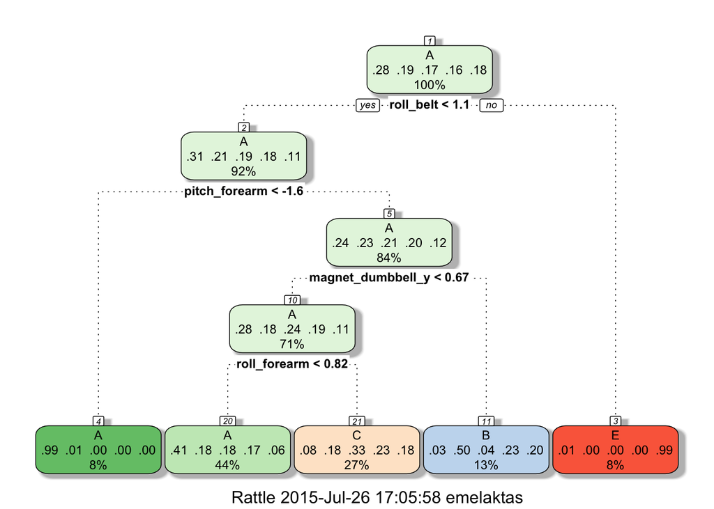

```r
# To use three repeats of 10–fold cross–validation
cvCtrl <- trainControl(method = "repeatedcv", repeats = 3)

# Build the machine learning model classification tree
modFit1 <- train(classe ~ ., data = trainingdata, preProcess=c("center", "scale"), method = "rpart", trControl = cvCtrl)

# Plot the tree
fancyRpartPlot(modFit1$finalModel)
```

```r
# Build the machine learning model random forest
modFit2 <- randomForest(classe ~ . , data = trainingdata)
```

## Expected out-of-sample error

```r
# Predict with the CART
prediction1 <- predict(modFit1, newdata = testingdata)
confusionMatrix(prediction1, testingdata$classe)
```

```
## Confusion Matrix and Statistics
##
##           Reference
## Prediction    A    B    C    D    E
##          A 1267  397  395  351  129
##          B   28  322   35  127  107
##          C   96  230  425  326  250
##          D    0    0    0    0    0
##          E    4    0    0    0  415
##
## Overall Statistics
##
##                Accuracy : 0.4953
##                  95% CI : (0.4812, 0.5094)
##     No Information Rate : 0.2845
##     P-Value [Acc > NIR] : < 2.2e-16
##
##                   Kappa : 0.3406
##  Mcnemar's Test P-Value : NA
##
## Statistics by Class:
##
##                      Class: A Class: B Class: C Class: D Class: E
## Sensitivity            0.9082  0.33930  0.49708   0.0000  0.46060
## Specificity            0.6375  0.92491  0.77723   1.0000  0.99900
## Pos Pred Value         0.4990  0.52019  0.32027      NaN  0.99045
## Neg Pred Value         0.9459  0.85368  0.87979   0.8361  0.89164
## Prevalence             0.2845  0.19352  0.17435   0.1639  0.18373
## Detection Rate         0.2584  0.06566  0.08666   0.0000  0.08462
## Detection Prevalence   0.5177  0.12622  0.27060   0.0000  0.08544
## Balanced Accuracy      0.7729  0.63210  0.63715   0.5000  0.72980
```

```r
# Predict with the Random Forest
prediction2 <- predict(modFit2, newdata = testingdata)
confusionMatrix(prediction2, testingdata$classe)
```

```
## Confusion Matrix and Statistics
##
##           Reference
## Prediction    A    B    C    D    E
##          A 1393    4    0    0    0
##          B    2  944    6    0    0
##          C    0    1  849    3    1
##          D    0    0    0  799    0
##          E    0    0    0    2  900
##
## Overall Statistics
##
##                Accuracy : 0.9961
##                  95% CI : (0.994, 0.9977)
##     No Information Rate : 0.2845
##     P-Value [Acc > NIR] : < 2.2e-16
##
##                   Kappa : 0.9951
##  Mcnemar's Test P-Value : NA
##
## Statistics by Class:
##
##                      Class: A Class: B Class: C Class: D Class: E
## Sensitivity            0.9986   0.9947   0.9930   0.9938   0.9989
## Specificity            0.9989   0.9980   0.9988   1.0000   0.9995
## Pos Pred Value         0.9971   0.9916   0.9941   1.0000   0.9978
## Neg Pred Value         0.9994   0.9987   0.9985   0.9988   0.9998
## Prevalence             0.2845   0.1935   0.1743   0.1639   0.1837
## Detection Rate         0.2841   0.1925   0.1731   0.1629   0.1835
## Detection Prevalence   0.2849   0.1941   0.1741   0.1629   0.1839
## Balanced Accuracy      0.9987   0.9964   0.9959   0.9969   0.9992
```

## Rationale and Conclusion

The prediction accuracy is much better with the Random Forests; hence I submitted the prediction from modFit2.

```r
# Predict test set with the Random Forest
predict(modFit2, newdata = predictionset)
```

```
##  1  2  3  4  5  6  7  8  9 10 11 12 13 14 15 16 17 18 19 20
##  B  A  B  A  A  E  D  B  A  A  B  C  B  A  E  E  A  B  B  B
## Levels: A B C D E
```

## References

Velloso, E.; Bulling, A.; Gellersen, H.; Ugulino, W.; Fuks, H. Qualitative Activity Recognition of Weight Lifting Exercises. Proceedings of 4th International Conference in Cooperation with SIGCHI (Augmented Human ’13) . Stuttgart, Germany: ACM SIGCHI, 2013.

Read more: http://groupware.les.inf.puc-rio.br/har#weight_lifting_exercises#ixzz3geVCgjEB